# Fitting a finite mixture of piecewise mixed-effect models with unknown random knots

Cengiz Zopluoglu

University of Oregon

09/5/2024

[Updated: Thu, Sep 05, 2024 - 23:01:51 ]

# 1. Overview

This tutorial demonstrates how to fit a finite mixture of piecewise mixed-effect models with unknown random knots using the R routine developed as described in [in our paper](https://github.com/czopluoglu/fitPMM/blob/main/paper/2015_Kohli%2C%20Harring%2C%20%26%20Zopluoglu.pdf). The R routine can be found in the [GitHub repository](https://github.com/czopluoglu/fitPMM) under the `/code` folder.

# 2. Installation and Setup

## 2.1 Download and Source the R Routine

First, download the R script file (fitPMM.R) from the repository and source it into your R environment.

```r
source('path_to_your_downloaded_code/fitPMM.R')
```

## 2.2 Install and Load Required Libraries

The routine depends on several R packages. If these are not installed, use install.packages() to install them before loading.

```r
# Uncomment the lines to install if needed
# install.packages("segmented",dependencies=TRUE)
# install.packages("glmmML",dependencies=TRUE)
# install.packages("MCMCpack",dependencies=TRUE)
# install.packages("psych",dependencies=TRUE)
# install.packages("MBESS",dependencies=TRUE)
# install.packages("gdata",dependencies=TRUE)

# Load the necessary libraries
    require(segmented)   # Fitting piecewise model to individual data, used to obtain start values
    require(glmmML)      # Using "ghq()" function
    require(MCMCpack)    # Using "xpnd()" function
    require(psych)       # Using "cor.smooth()" function
    require(MBESS)       # Using "cor2cov()" function
    require(gdata)       # Using "write.fwf()" function
```

# 3. Loading the dataset

We will use a random subsample of [The Early Childhood Longitudinal Study (ECLS-K)](http://nces.ed.gov/ecls/) . This dataset tracks children’s progress from kindergarten through eighth grade. The time vector (`tvec`) represents specific intervals in the study.

First, download the data file from the folder [/data/](https://github.com/czopluoglu/fitPMM/tree/main/data) in the GitHub repository, and then load it into your R environment

```r
load(''path_to_your_downloaded_RData_file/ECLS.RData')  # Load the dataset
tvec <- c(0, 0.5, 1, 1.5, 3.5, 5.5, 8.5)  # Time points vector

head(ECLS)
```

```
        M1    M2    M3    M4     M5     M6     M7
[1,] 28.14 50.51 45.89 93.65 152.42 163.89 171.23
[2,] 27.04 42.23 48.73 66.21 112.09 125.56 155.11
[3,] 43.45 56.71 70.53 89.71 137.38 159.14 169.89
[4,] 16.52 32.48 38.07 47.97 117.71 139.88 166.58
[5,] 28.87 43.53 48.07 77.39 100.41 138.46 150.94
[6,] 15.57 30.53 35.33 50.68  77.26 116.04 139.39
```

The time points represent:

- 0 — Kindergarten (fall)
- 0.5 — Kindergarten (spring)
- 1 — 1st Grade (fall)
- 1.5 — 1st Grade (spring)
- 3.5 — 3rd Grade (spring)
- 5.5 — 5th Grade (spring)
- 8.5 — 8th Grade (spring)

# 4. Generate starting values for the algorithm

The algorithm is sensitive to starting values. To improve convergence, we’ll estimate initial parameters (intercepts, slopes, knots, and residual variance) by fitting piecewise models to each individual’s data. These estimates will then be passed into the main model fitting function.

```r
# Time vector
tvec = c(0,.5,1,1.5,3.5,5.5,8.5)  # Time vector

# Sample size, number of rows in the dataset

N <- nrow(ECLS) # Sample size

ind_par <- matrix(nrow=N,ncol=5)  # Matrix to store individual parameter estimates

colnames(ind_par) <- c("B1","B2","B3","K","Sigma")

    # B1   : The intercept at the first phase
        # B2   : The slope at the first phase
        # B3   : The slope at the second phase
        # K    : Knot, change/break point between two phases
        # sigma: Residual Variance

K.st <- 3       # Initial guess for the knot

# The following loop may take some time depending on your sample size.
# It fits piecewise linear model to each individual data,
# and estimates B1, B2, B3, K, and sigma for each individual

for(i in 1:nrow(ECLS)) {

  tryCatch({

    y <- as.numeric(ECLS[i,])

        if(sum(is.na(y))<=3){ # Ensure there are enough data points

            lm.out <- lm(y~tvec)

            out    <- segmented(lm.out,seg.Z=~tvec,psi=K.st)

            if(is.null(out)!=TRUE & length(coef(out))==4) {
                ind_par[i,1:2] <- as.numeric(coef(out))[1:2]    # B1, B2
                ind_par[i,3] <- ind_par[i,2]+as.numeric(coef(out))[3]  # B3
                  ind_par[i,4]<- out$psi[2]              # Knot
                ind_par[i,5]<- (summary(out)$sigma)^2   # Residual variance
                }
        }
  }, error=function(e){})
}
```

```
breakpoint estimate(s): 5.632143
breakpoint estimate(s): 5.586353
breakpoint estimate(s): 5.632143
breakpoint estimate(s): 5.632143
```

```r
head(ind_par)      # Preview of individual estimates
```

```
           B1       B2       B3        K      Sigma
[1,] 27.23349 36.06808 2.446667 3.664326 161.406148
[2,] 27.45100 24.80200 8.702368 3.273689   9.949666
[3,] 44.44425 27.00904 3.583333 4.054837   9.501908
[4,] 13.21062 28.72260 8.900000 3.920746  45.008824
[5,] 33.01219 20.49370 4.160000 5.055059  83.835010
[6,] 18.96272 17.83219 8.312265 5.240590  21.495534
```

# 5. Fitting the model

Now, use the `fitPMM()` function to fit the mixture model. This function requires several arguments, including the dataset, starting values, and model-specific options such as the number of latent classes and quadrature points.

```r
fit <- fitPMM(
  data     = ECLS,     # Dataset
  start    = ind_par,  # Starting values
  time.vec = tvec,     # Time vector
  L        = 2,        # Number of latent classes
  nquad    = 20,       # Number of quadrature points
  isnit_max= 15,       # Max iterations for initial stage
  is_st    = 0.001,    # Stopping criteria for initial stage
  is_nset  = 500,      # Number of starting sets for initial stage
  fsnit_max= 2000,     # Max iterations for final stage
  fs_st    = 0.0001,   # Stopping criteria for final stage
  fs_nset  = 3,        # Number of starting sets for final stage
  sel      = 2,        # Optimization method (1 = BFGS, 2 = DFPQ)
  fix.cov  = TRUE,    # Fix variance-covariance across classes?
  fix.err  = TRUE     # Fix residual variance across classes?
)
```

```
An R Routine to Fit Finite Mixture of Piecewise Mixed-Effect Models with Unknown Random Knots

Maintainer: Cengiz Zopluoglu
            University of Oregon

Email     : cengiz@uoregon.edu
Please use the following citation for any use of this R routine.

     Zopluoglu, C., Harring, J.R., Kohli,N. (2014). FitPMM: An R Routine to Fit
         Finite Mixture of Piecewise Mixed-Effect Models With Unknown Random Knots.
         Applied Psychological Measurement, 38(7), 583-584


Processing Date:  Thu Sep  5 23:02:27 2024

```

[output cut: 13674 more lines]

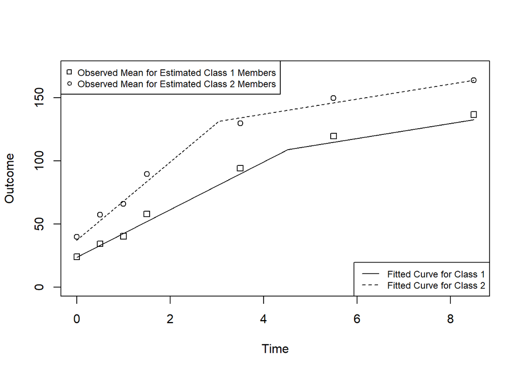

# 6. Model output

The model will return several outputs, including parameter estimates and class memberships.

```r
fit$PAR         # Parameter estimates
```

```
   Class         Parameter       Est       SE
1      1    B1 (Intercept) 23.688573 0.674819
2      1      B2 (Slope 1) 18.852256 0.086427
3      1      B3 (Slope 2)  5.933631  0.37895
4      1          K (Knot)  4.514511 0.110992
5      1 Residual Variance 52.298932 2.833802
6      1       B1 variance 23.058805      NaN
7      1       B2 variance 22.020641      NaN
8      1       B3 variance  5.979795 1.634661
9      1        K variance   0.27651 0.082748
10     1   B1B2 Covariance 17.802324 4.126175
11     1   B1B3 Covariance -2.874818 2.260618
12     1    B1K Covariance -1.234489 0.370868
13     1   B2B3 Covariance -2.093873 1.509699
14     1    B2K Covariance -0.835986 0.354698
15     1    B3K Covariance -0.994436 0.313185
16     2    B1 (Intercept) 37.265515      NaN
17     2      B2 (Slope 1)  30.89854 1.228654
18     2      B3 (Slope 2)  5.938897 0.547535
19     2          K (Knot)  3.041259 0.130155
```

```r
fit$CP          # Class proportions
```

```
[1] 0.8110258 0.1889742
```

```r
fit$POSTERIOR   # Posterior probabilities and class memberships
```

```
       M1    M2    M3     M4     M5     M6     M7     P1     P2 Class
1   28.14 50.51 45.89  93.65 152.42 163.89 171.23 0.1749 0.8251     2
2   27.04 42.23 48.73  66.21 112.09 125.56 155.11 0.8646 0.1354     1
3   43.45 56.71 70.53  89.71 137.38 159.14 169.89 0.0491 0.9509     2
4   16.52 32.48 38.07  47.97 117.71 139.88 166.58 0.9970 0.0030     1
5   28.87 43.53 48.07  77.39 100.41 138.46 150.94 0.9140 0.0860     1
6   15.57 30.53 35.33  50.68  77.26 116.04 139.39 0.9989 0.0011     1
7   20.56 28.42 30.63  48.33  74.73  94.36 127.25 0.9987 0.0013     1
8   24.88 32.53 35.08  54.94  88.21 127.21 155.05 0.9960 0.0040     1
9   24.41 33.92 49.08  53.64  83.35  99.84 103.28 0.9905 0.0095     1
10  40.19 56.03 68.60  96.95 117.46 140.97 158.33 0.0037 0.9963     2
11  18.49 20.73 27.45  47.34  68.83  84.47 112.45 0.9996 0.0004     1
12  22.44 36.06 29.80  45.55  65.58  93.96 111.00 0.9994 0.0006     1
13  27.88 40.81 45.04  75.80 109.66 134.77 144.89 0.8795 0.1205     1
14  35.59 57.53 57.60 110.97 131.91 151.68 171.39 0.0053 0.9947     2
```

[output cut: 186 more lines]